# UpVotes Challenge: Analysis and Prediction

Author: Anderson Hoff

Last update: 17 abril, 2020

## OVERVIEW

The main objective of this project is to learn and practice some technical duties about data analysis and graphic generation. Also, I tested different predictive models, focused on the behavior and differences between them. Last, but not least, that is an excellent oportunity to practice my English skills.

The challenge of this problem is to identify the best question authors from an on-line question and answer platform. This identification will bring more insight into increasing the user engagement. By this way, given the tag of the question, number of views received, number of answers, username and reputation of the question author, the problem requires you to predict the up votes number that determined question will receives.

This test is provided by [Analytics Vidhya](https://datahack.analyticsvidhya.com/contest/enigma-codefest-machine-learning-1/).

## REQUIRED PACKAGES

```r
#if(!require(dplyr)) {istall.packages("dplyr")} else {library(dplyr)}
library(dplyr)
library(ggplot2)
library(magrittr) # for pipe
library(caTools) # for data partition
library(ModelMetrics) # for rmse
library(corrplot) # correlation matrix
library(knitr) # for floating tables
library(neuralnet)
library(xgboost)
library(Matrix)
library(Ckmeans.1d.dp)
library(keras)
```

## DATA

The data used in this analysis is composed by a training set and a test set. In this part I will be dealing with the training dataset. This is how it looks like.

| Upvotes | ID | Tag | Reputation | Answers | Username | Views |
| --- | --- | --- | --- | --- | --- | --- |
| 42 | 52664 | a | 3942 | 2 | 155623 | 7855 |
| 1175 | 327662 | a | 26046 | 12 | 21781 | 55801 |
| 60 | 468453 | c | 1358 | 4 | 56177 | 8067 |
| 9 | 96996 | a | 264 | 3 | 168793 | 27064 |
| 83 | 131465 | c | 4271 | 4 | 112223 | 13986 |
| 4 | 345568 | r | 440 | 1 | 23866 | 5577 |
| 17 | 376865 | c | 147 | 1 | 10759 | 17184 |
| 3 | 467378 | j | 2269 | 2 | 54623 | 312 |
| 79 | 393640 | j | 111 | 2 | 172926 | 53738 |
| 0 | 130054 | c | 2749 | 1 | 10189 | 227 |

| Variable | Definition |
| --- | --- |
| Upvotes | Number of upvotes for the question (TARGET) |
| ID | Question ID |
| Tag | Anonymised tags representing question category |
| Reputation | Reputation score of author |
| Answer | Number of times question has been answered |
| Username | Anonymised user id of question author |
| Views | Number of times question has been viewed |

As can be seen, the target is to predict the number of positive votes a question receive, based on the features described above.  
The table below show the type of each column of the data. Apart from “TAG”, all other columns are numeric.

```
## Observations: 330,045
## Variables: 7
## $ Upvotes    <dbl> 42, 1175, 60, 9, 83, 4, 17, 3, 79, 0, 166, 42, 19, ...
## $ ID         <int> 52664, 327662, 468453, 96996, 131465, 345568, 37686...
## $ Tag        <fct> a, a, c, a, c, r, c, j, j, c, c, p, s, h, o, c, i, ...
## $ Reputation <dbl> 3942, 26046, 1358, 264, 4271, 440, 147, 2269, 111, ...
## $ Answers    <dbl> 2, 12, 4, 3, 4, 1, 1, 2, 2, 1, 7, 1, 4, 1, 2, 2, 4,...
## $ Username   <int> 155623, 21781, 56177, 168793, 112223, 23866, 10759,...
## $ Views      <dbl> 7855, 55801, 8067, 27064, 13986, 5577, 17184, 312, ...
```

It is important to identify missing values (NA’s) on the tables, from both numeric ans categorical data. The result obtained below tell us that there are not empty cells in the numeric columns.

```r
sum(is.na(train_data))
```

```
## [1] 0
```

```r
levels(train_data$Tag)
```

```
##  [1] "a" "c" "h" "i" "j" "o" "p" "r" "s" "x"
```

Also, there is not a blank categorical cell in the TAG column, since the line above contain only letters.  
These results means the dataset is usable and we can start try to extract relevant information from it.

## GRAPHS

### Tag

The table below show us the question category is spread in different letters, and the graph indicates that it is reasobly distributed between them.

```r
table(train_data$Tag)
```

```
##
##     a     c     h     i     j     o     p     r     s     x
## 31695 72458 20564 32400 72232 14546 43407 12442 23323  6978
```

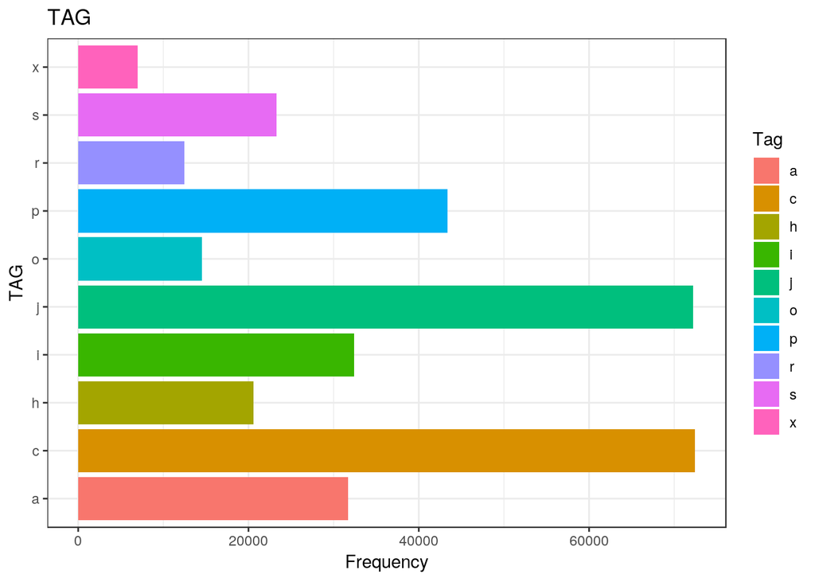

```r
ggplot(train_data, aes(x=Tag)) +
  geom_bar(aes(fill=Tag)) +
  ggtitle("TAG")+
  coord_flip()+
  theme_bw()+
  ylab("Frequency")+
  xlab("TAG")
```

### Reputation

```r
summary(train_data$Reputation)
```

```
##    Min. 1st Qu.  Median    Mean 3rd Qu.    Max.
##       0     282    1236    7773    5118 1042428
```

```r
reputation_groups <- cut(train_data$Reputation, breaks = 10, labels = FALSE)
table(reputation_groups)
```

```
## reputation_groups
##      1      2      3      4      5      6      7      8     10
## 326365   2418    695    402     83     32     18     26      6
```

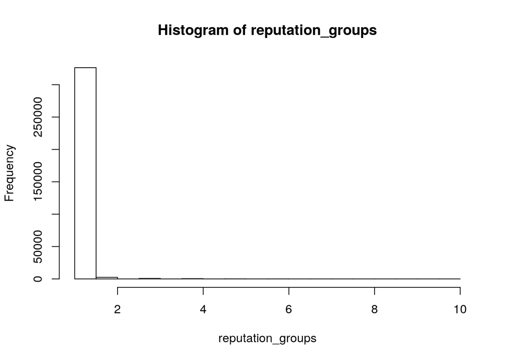

```r
hist(reputation_groups)
```

From the table above, we observe that almost all of Reputation data is in the first column. This means most of the Reputation is low.

### Answers

```r
summary(train_data$Answers)
```

```
##    Min. 1st Qu.  Median    Mean 3rd Qu.    Max.
##   0,000   2,000   3,000   3,918   5,000  76,000
```

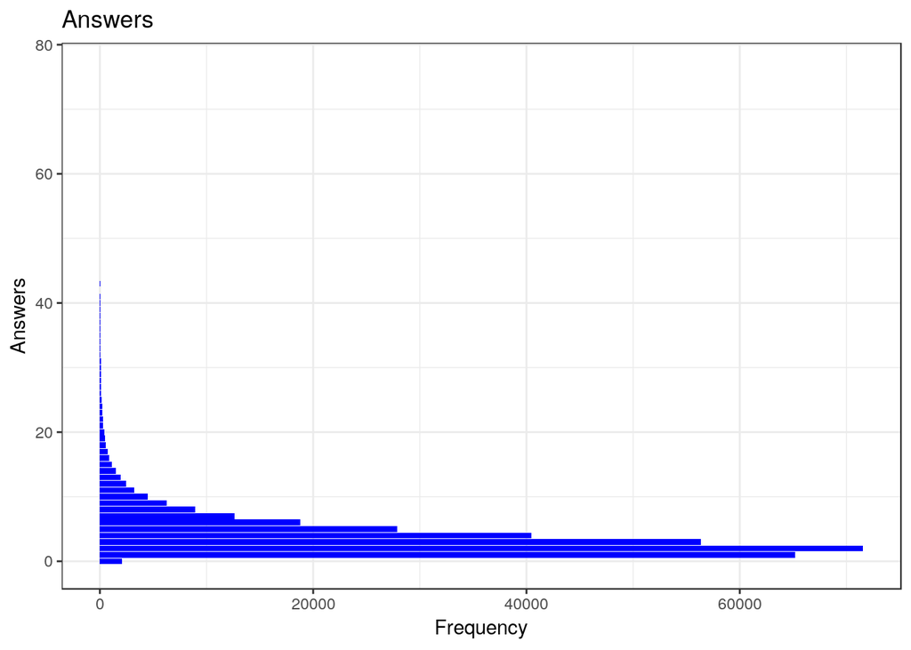

```r
ggplot(train_data, aes(x=Answers)) +
  geom_bar(fill = "blue") +
  ggtitle("Answers")+
  coord_flip()+
  theme_bw()+
  ylab("Frequency")+
  xlab("Answers")
```

From the diagram above, most of the questions have a small number of answers. One question that arises is if there is a correlation between the number of answers and the upvotes.

### Usernames

```r
summary(train_data$Username)
```

```
##    Min. 1st Qu.  Median    Mean 3rd Qu.    Max.
##       0   39808   79010   81443  122559  175738
```

```r
Usernames <- cut(train_data$Username, breaks = 10, labels = FALSE)
table(Usernames)
```

```
## Usernames
##     1     2     3     4     5     6     7     8     9    10
## 37422 36315 36779 36430 36276 34934 30266 30800 27834 22989
```

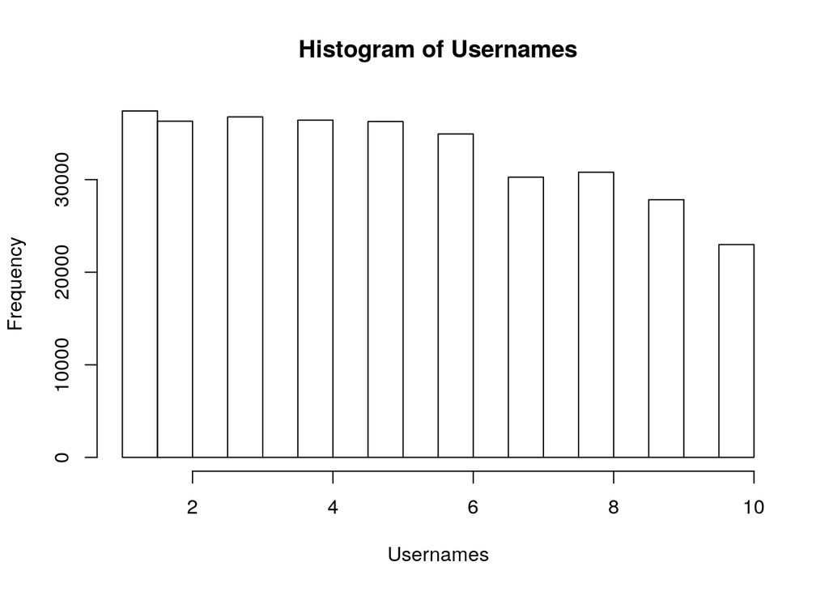

```r
hist(Usernames)
```

```r
#ggplot(train_data, aes(x=Username)) +
#  geom_bar(aes(fill = Username)) +
#  ggtitle("Usernames frequency")+
#  coord_flip()+
#  ylab("Number of frequency")+
#  xlab("Usernames")
```

### Views

```r
summary(train_data$Views)
```

```
##    Min. 1st Qu.  Median    Mean 3rd Qu.    Max.
##       9    2594    8954   29645   26870 5231058
```

```r
Views <- cut(train_data$Views, breaks = 10, labels = FALSE)
table(Views)
```

```
## Views
##      1      2      3      4      5      6      7      8      9     10
## 328761    990    188     57     25     14      4      2      1      3
```

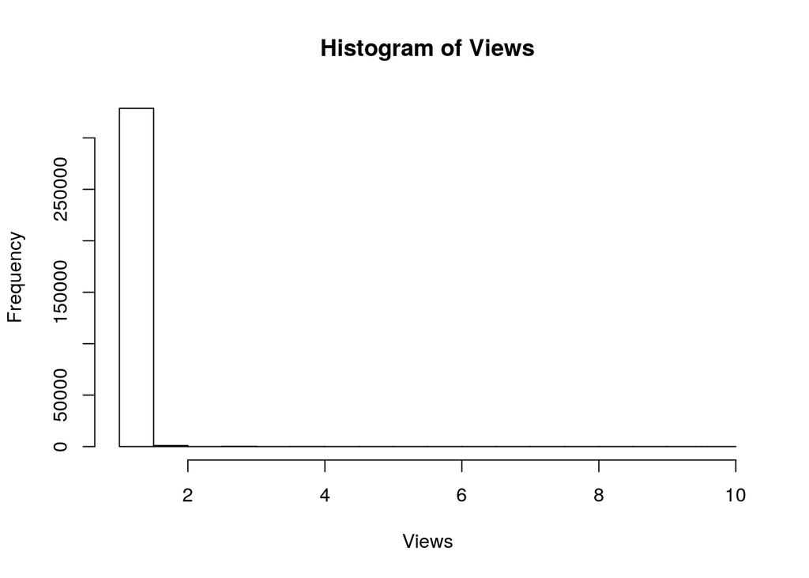

```r
hist(Views)
```

### Upvotes

```r
summary(train_data$Upvotes)
```

```
##     Min.  1st Qu.   Median     Mean  3rd Qu.     Max.
##      0,0      8,0     28,0    337,5    107,0 615278,0
```

```r
Upvotes <- cut(train_data$Upvotes, breaks = 10, labels = FALSE)
table(Upvotes)
```

```
## Upvotes
##      1      2      3      4      5      6      8     10
## 329918     85     26      3      5      3      3      2
```

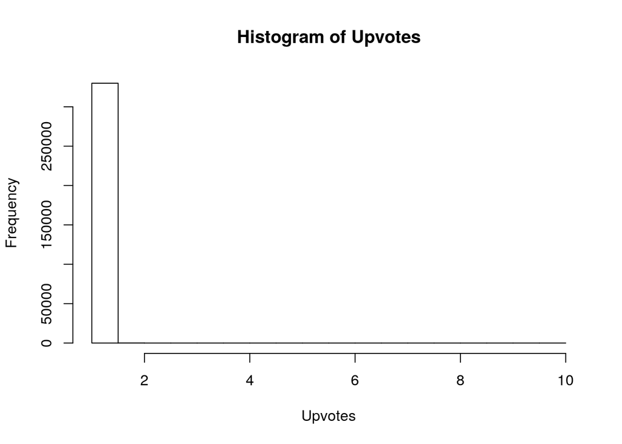

```r
hist(Upvotes)
```

### Corr. Matrix

In statistics, the correlation coefficient *cc* measures the strength and direction of a linear relationship between two variables on a scatterplot. The value of *cc* is always between +1 and –1. To interpret its value, see which of the following values your correlation *cc* is closest to:

- -1 : indicates a strong negative correlation (if one variable increases, the other decreases).
- 0 : there is no association between the two variables.
- +1 : indicates a stron positive correlation: (both variables vary in the same way).

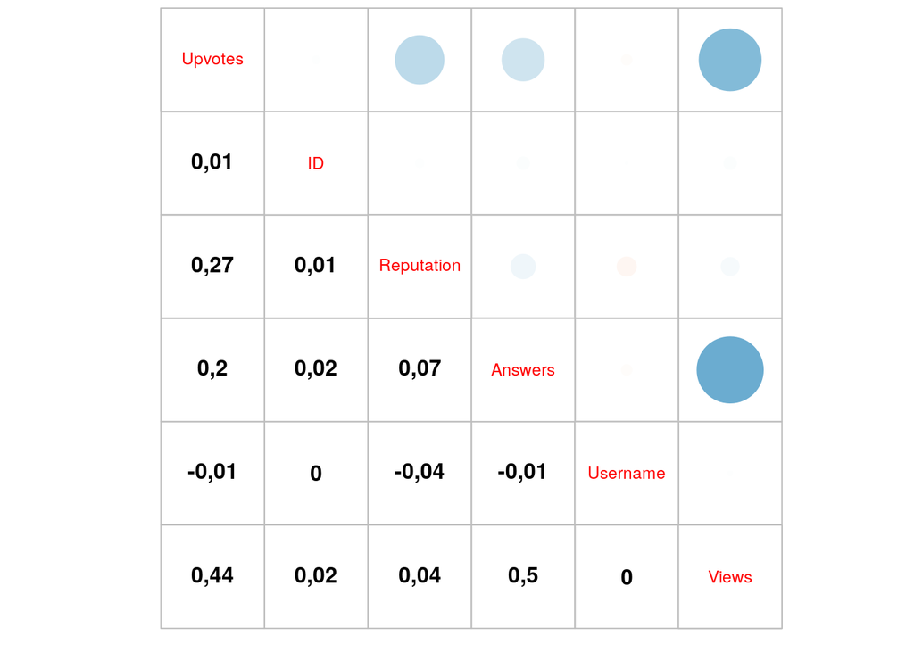

```r
numeric.var <- sapply(train_data, is.numeric)
corr.matrix <- cor(train_data[,numeric.var])
corrplot(corr.matrix, order = "original", type="upper", diag = TRUE, tl.pos = "n", cl.pos = "n")
corrplot(corr.matrix, add = TRUE, type = "lower", method = "number",
         order = "original", col = "black", diag = TRUE, tl.pos = "d", tl.cex = 0.77, cl.pos = "n")
```

```r
train_data <- train_data %>%
  select( -Username)
```

## PREDICTIVE MODELS

We start here the data forecast for this problem, Only to emphasize, the evaluation metric for this competition is RMSE (root mean squared error). The RMSE is a standard way to measure the error of a model in predicting quantitative data. Formally it is defined as
$$RMSE = \sqrt{\sum(ŷ_i - y_i)/n}$$
The RMSE can be tought as a distance between the vector of predicted values and the vector of observed values.

### Linear Regression Model

```r
set.seed(seed = 2019)
split = sample.split(train_data, SplitRatio = 0.7)
train_set = subset(train_data, split == TRUE)
test_set = subset(train_data, split == FALSE)

lmmodel <- lm(Upvotes ~ +Tag +Reputation +Answers +Views,
              data = train_set, singular.ok = TRUE)
anova(lmmodel)
```

```
## Analysis of Variance Table
##
## Response: Upvotes
##                Df     Sum Sq    Mean Sq   F value    Pr(>F)
## Tag             9 4,5883e+09 5,0982e+08    56,258 < 2,2e-16 ***
## Reputation      1 2,0092e+11 2,0092e+11 22171,888 < 2,2e-16 ***
## Answers         1 8,7742e+10 8,7742e+10  9682,378 < 2,2e-16 ***
## Views           1 3,6176e+11 3,6176e+11 39920,532 < 2,2e-16 ***
## Residuals  220016 1,9938e+12 9,0621e+06
## ---
## Signif. codes:  0 '***' 0,001 '**' 0,01 '*' 0,05 '.' 0,1 ' ' 1
```

```r
summary(lmmodel)
```

```
##
## Call:
## lm(formula = Upvotes ~ +Tag + Reputation + Answers + Views, data = train_set,
##     singular.ok = TRUE)
##
## Residuals:
##    Min     1Q Median     3Q    Max
## -40174   -113    186    343 566431
##
## Coefficients:
##               Estimate Std. Error t value Pr(>|t|)
## (Intercept) -3,478e+02  2,218e+01 -15,684  < 2e-16 ***
## Tagc        -7,015e+01  2,486e+01  -2,821 0,004783 **
## Tagh        -2,797e+01  3,298e+01  -0,848 0,396401
## Tagi         1,051e+02  2,921e+01   3,600 0,000319 ***
## Tagj        -6,630e+01  2,489e+01  -2,664 0,007725 **
## Tago         1,168e+02  3,696e+01   3,160 0,001576 **
## Tagp        -3,238e+01  2,730e+01  -1,186 0,235587
## Tagr         9,121e+01  3,901e+01   2,338 0,019377 *
## Tags        -1,313e+01  3,183e+01  -0,413 0,679882
## Tagx         7,672e+01  4,889e+01   1,569 0,116636
## Reputation   3,380e-02  2,378e-04 142,157  < 2e-16 ***
## Answers     -2,941e+01  2,088e+00 -14,088  < 2e-16 ***
## Views        1,861e-02  9,316e-05 199,801  < 2e-16 ***
## ---
## Signif. codes:  0 '***' 0,001 '**' 0,01 '*' 0,05 '.' 0,1 ' ' 1
##
## Residual standard error: 3010 on 220016 degrees of freedom
## Multiple R-squared:  0,2473, Adjusted R-squared:  0,2472
## F-statistic:  6023 on 12 and 220016 DF,  p-value: < 2,2e-16
```

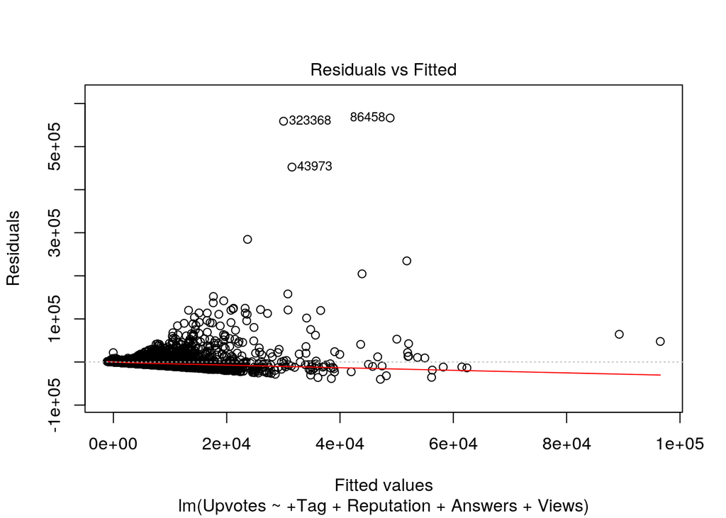

```r
plot(lmmodel, which=1, caption = list("Residuals vs Fitted"))
```

This plot shows if residuals have non-linear patterns. There could be a non-linear relationship between predictor variables and an outcome variable and the pattern could show up in this plot if the model doesn’t capture the non-linear relationship.

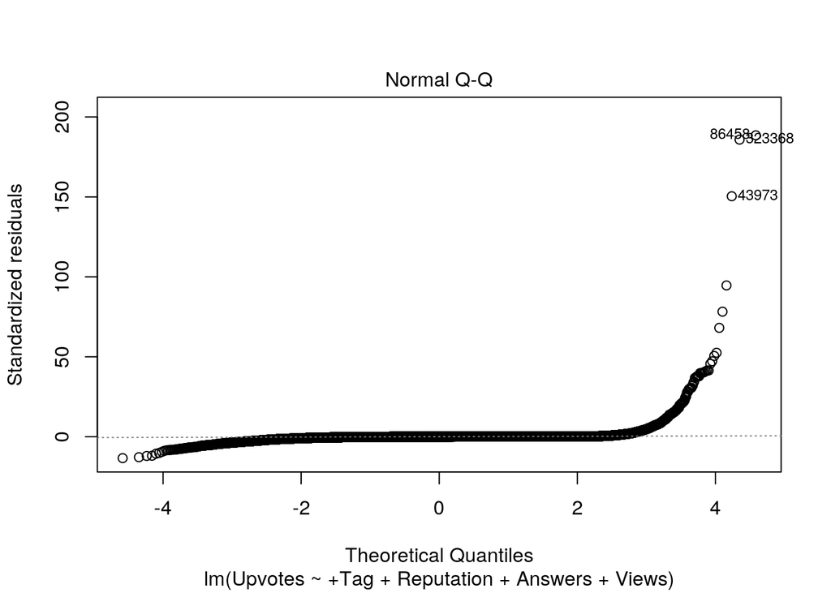

```r
plot(lmmodel, which=2, caption = list("", "Normal Q-Q"))
```

This plot shows if residuals are normally distributed. Do residuals follow a straight line well or do they deviate severely? It’s good if residuals are lined well on the straight dashed line.

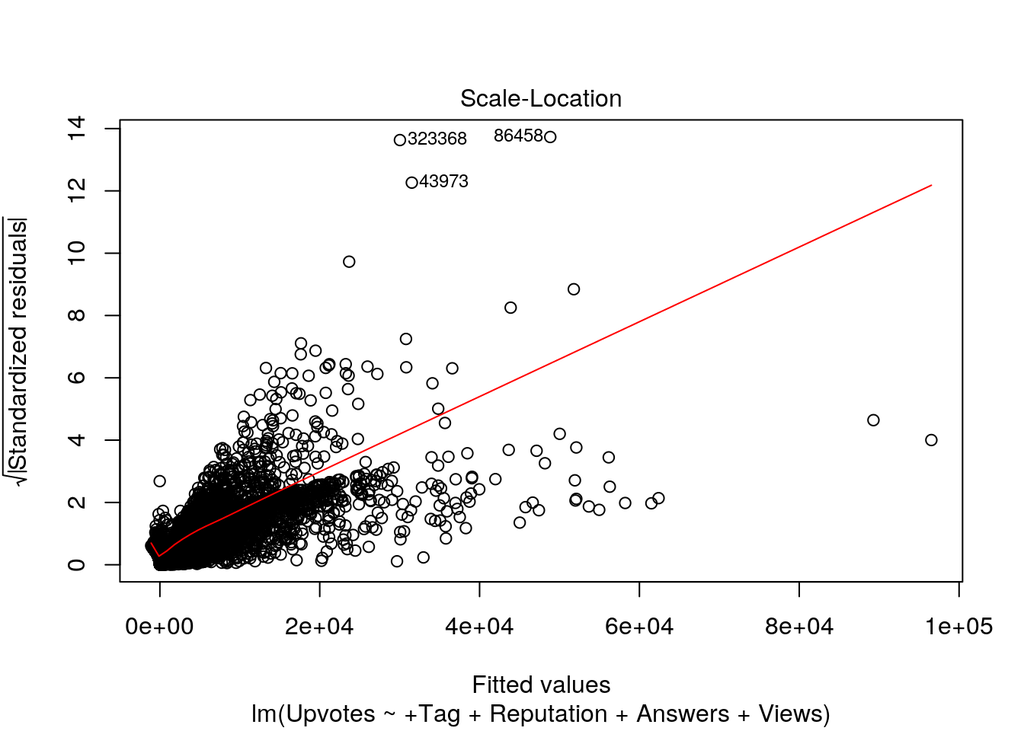

```r
plot(lmmodel, which=3, caption = list("", "", "Scale-Location"))
```

It’s also called Spread-Location plot. This plot shows if residuals are spread equally along the ranges of predictors. This is how you can check the assumption of equal variance (homoscedasticity). It’s good if you see a horizontal line with equally (randomly) spread points.

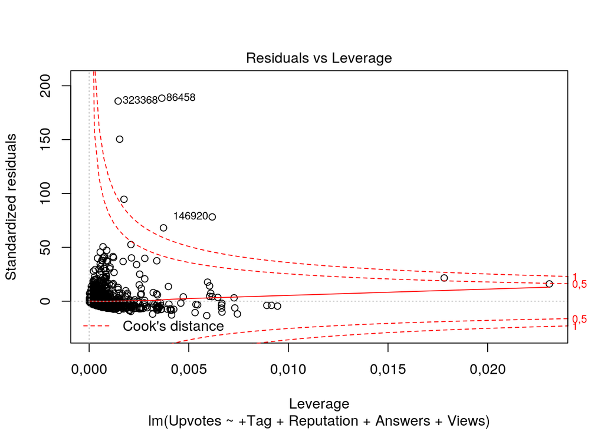

```r
plot(lmmodel, which=5, caption = list("", "", "", "", "Residuals vs Leverage"))
```

This plot helps us to find influential cases (i.e., subjects) if any. Not all outliers are influential in linear regression analysis (whatever outliers mean). Even though data have extreme values, they might not be influential to determine a regression line. That means, the results wouldn’t be much different if we either include or exclude them from analysis. They follow the trend in the majority of cases and they don’t really matter; they are not influential. On the other hand, some cases could be very influential even if they look to be within a reasonable range of the values. They could be extreme cases against a regression line and can alter the results if we exclude them from analysis. Another way to put it is that they don’t get along with the trend in the majority of the cases.

Source of graphic explanation: [University of Virginia](https://data.library.virginia.edu/diagnostic-plots/)  
The following step is to predict the test set results, based on this trained model. The test set corresponds to 30% of the data. Further, we can calculate the RMSE for the obtained results.

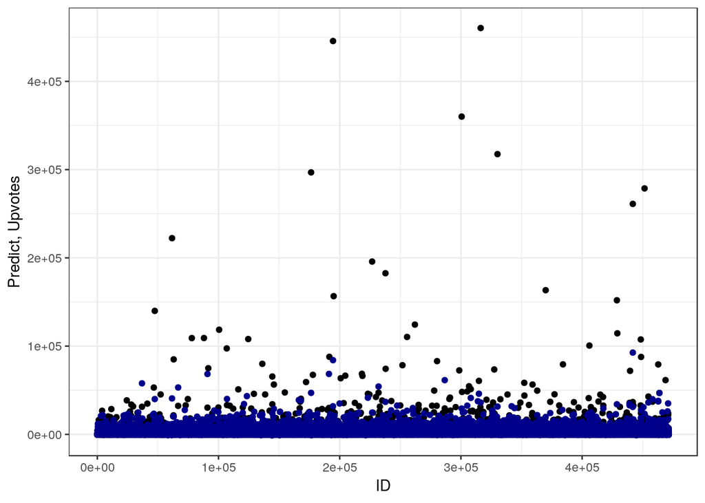

```r
predict_lm <- predict(lmmodel, newdata =  test_set,
                                        type = "response",
                                        interval = "confidence",
                                        family = poisson(link = ))

predict <- as.data.frame(predict_lm)

test_set$predict <- predict$fit

ggplot()+
  geom_point(data=test_set, aes(x=ID, y=Upvotes), fill="red") +
  geom_point(data=test_set, aes(x=ID, y=predict), fill="blue", colour="darkblue")+
  theme_bw()+
  ylab("Predict, Upvotes")+
  xlab("ID")
```

```r
rmse_lm <- as.integer(rmse(test_set$Upvotes, test_set$predict))
```

The RMSE for the testing sample is 3274.

To generate the results for the Testing sample, run the code below for the testing sample, after the data preparation, in the same way as the training sample. This will generate a .csv file with the respective results, which can be send to the site for automatic evaluation.

```r
test_data = read.csv('test_data.csv')
test_data$predict <- predict.lm(lmmodel, newdata = test_data,
                                type = "response",
                                interval = "confidence",
                                family = poisson())

test_data$predict <- as.integer(test_data$predict)

write.table(cbind(test_data$ID,test_data$predict),
            file="Upvotes_LR.csv",
            sep = ",", quote = FALSE, col.names = c('ID','Upvotes'),
            row.names=F)
```

This procedure is the same for any other techniques, so I will not repeat it.

### Non-Linear Regresion Model

```r
set.seed(seed = 2020)
split = sample.split(train_data, SplitRatio = 0.7)
train_set = subset(train_data, split == TRUE)
test_set = subset(train_data, split == FALSE)

glmmodel <- glm(Upvotes ~ +Tag +Reputation +Answers +Views,
                train_set, family = quasi(link = "identity"))

summary(glmmodel)
```

```
##
## Call:
## glm(formula = Upvotes ~ +Tag + Reputation + Answers + Views,
##     family = quasi(link = "identity"), data = train_set)
##
## Deviance Residuals:
##    Min      1Q  Median      3Q     Max
## -43527    -111     198     364  564518
##
## Coefficients:
##               Estimate Std. Error t value Pr(>|t|)
## (Intercept) -3,690e+02  2,347e+01 -15,721  < 2e-16 ***
## Tagc        -5,861e+01  2,630e+01  -2,229 0,025841 *
## Tagh        -3,611e+01  3,485e+01  -1,036 0,300118
## Tagi         1,291e+02  3,082e+01   4,190 2,79e-05 ***
## Tagj        -5,618e+01  2,629e+01  -2,137 0,032632 *
## Tago         1,458e+02  3,914e+01   3,724 0,000196 ***
## Tagp        -1,881e+01  2,883e+01  -0,652 0,514258
## Tagr         1,113e+02  4,144e+01   2,685 0,007260 **
## Tags        -6,105e+00  3,362e+01  -0,182 0,855901
## Tagx         9,568e+01  5,145e+01   1,860 0,062921 .
## Reputation   3,324e-02  2,529e-04 131,427  < 2e-16 ***
## Answers     -3,522e+01  2,203e+00 -15,988  < 2e-16 ***
## Views        1,995e-02  9,666e-05 206,395  < 2e-16 ***
## ---
## Signif. codes:  0 '***' 0,001 '**' 0,01 '*' 0,05 '.' 0,1 ' ' 1
##
## (Dispersion parameter for quasi family taken to be 10102341)
##
##     Null deviance: 2,9510e+12  on 220028  degrees of freedom
## Residual deviance: 2,2227e+12  on 220016  degrees of freedom
## AIC: NA
##
## Number of Fisher Scoring iterations: 2
```

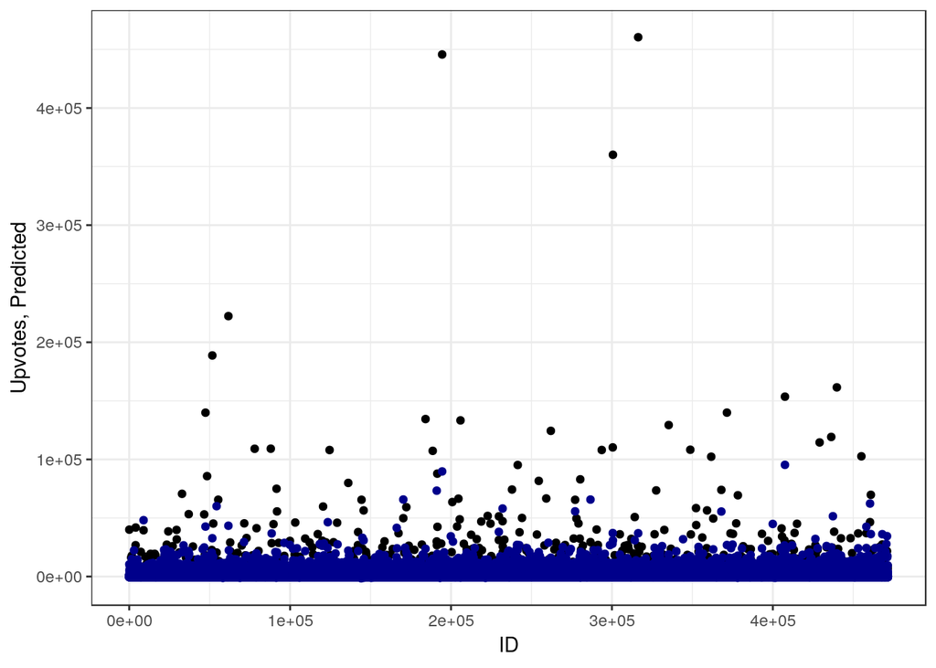

```r
test_set$predict <- predict.glm(glmmodel, newdata =  test_set,
                                type = "response",
                                family = poisson())

ggplot()+
  geom_point(data=test_set, aes(x=ID, y=Upvotes), fill="red") +
  geom_point(data=test_set, aes(x=ID, y=predict), fill="blue", colour="darkblue")+
  theme_bw()+
  ylab("Upvotes, Predicted")+
  xlab("ID")
```

```r
rmse_nlm <- as.integer(rmse(test_set$Upvotes, test_set$predict))
```

The RMSE for the testing sample is 2935.

### Neural net prediction

This is under development…

```r
train_net <- train_data %>%
  select(-Tag, - Upvotes)

Upvotes <- select(train_data, 1)

norm.fun = function(x){
  (x - min(x))/(max(x) - min(x))
}

data.norm = apply(train_net, 2, norm.fun)

data <- as.data.frame(data.norm)

train_net <- cbind(Upvotes, data)

set.seed(seed = 2019)
split = sample.split(train_net, SplitRatio = 0.1)#SplitRatio indicates the size of the training set
train_set = subset(train_net, split == TRUE)
test_set = subset(train_net, split == FALSE)


nnmodel <- neuralnet(train_net$Upvotes ~ +Reputation +Answers +Views,
                     data = train_net,
                     linear.output = FALSE,
                     hidden = 2,
                     threshold=0.01,
                     lifesign = "minimum",
                     rep = 3)
#print(nnmodel)
#plot(nnmodel)
```

### XGBoost analysis

```r
set.seed(seed = 2020)
split = sample.split(train_data, SplitRatio = 0.7)
train_set = subset(train_data, split == TRUE)
test_set = subset(train_data, split == FALSE)
```

```r
traindumb <- sparse.model.matrix(Upvotes ~. -1 , data = train_set)

train_label <- train_set[,"Upvotes"]

mtrain_set <- xgb.DMatrix(data = as.matrix(traindumb), label = train_label)
#print(mtrain_set, verbose = TRUE)

testdumb <- sparse.model.matrix(Upvotes ~. -1, data = test_set)

test_label <- test_set[,"Upvotes"]

mtest_set <- xgb.DMatrix(data = as.matrix(testdumb), label = test_label)

xgb_param <- list("booster" = "gblinear",
                  "lambda L2" = 1,
                  "objective" = "reg:logistic",
                  "eval_metric" = "rmsle")

watchlist <- list(train = mtrain_set, test = mtest_set)
```

```r
xgbmodel <- xgb.train(parameters = xgb_param,
                      data = mtrain_set,
                      max.depth = 10,
                      watchlist = watchlist,
                      verbose = 0,
                      nrounds = 40,
                      eta = 0.1)
```

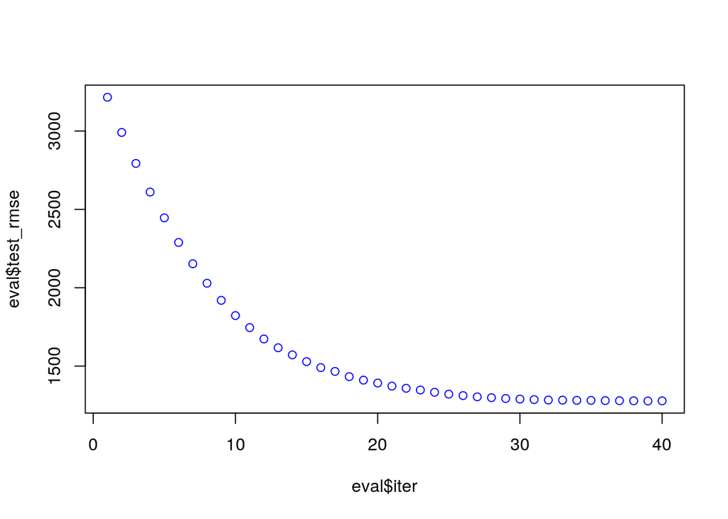

```r
eval <- data.frame(xgbmodel$evaluation_log)
plot(eval$iter, eval$test_rmse, col = 'blue')
```

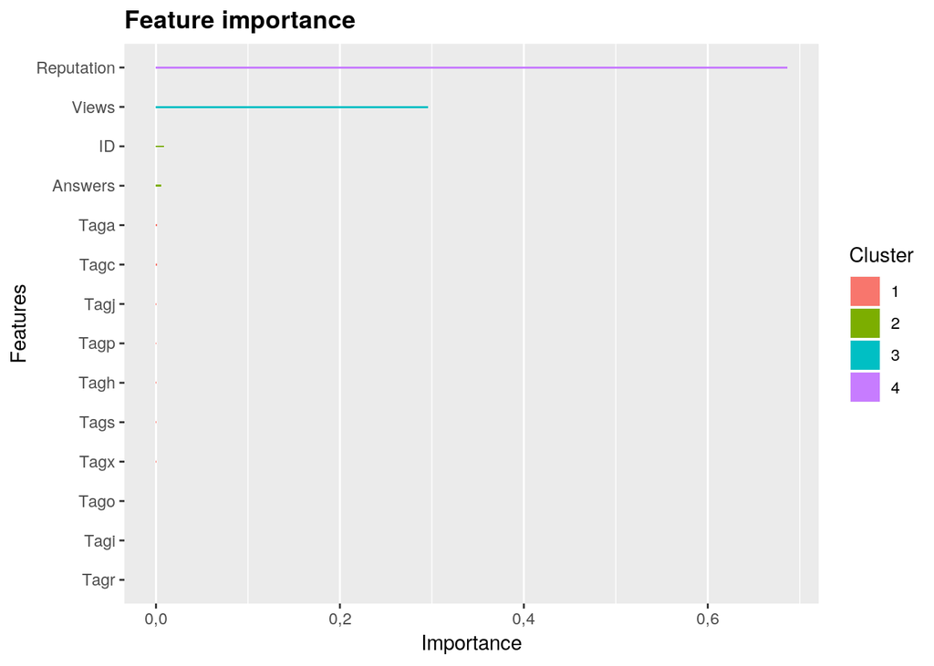

```r
xgbimpor<- xgb.importance(model = xgbmodel)
xgb.ggplot.importance(xgbimpor)
```

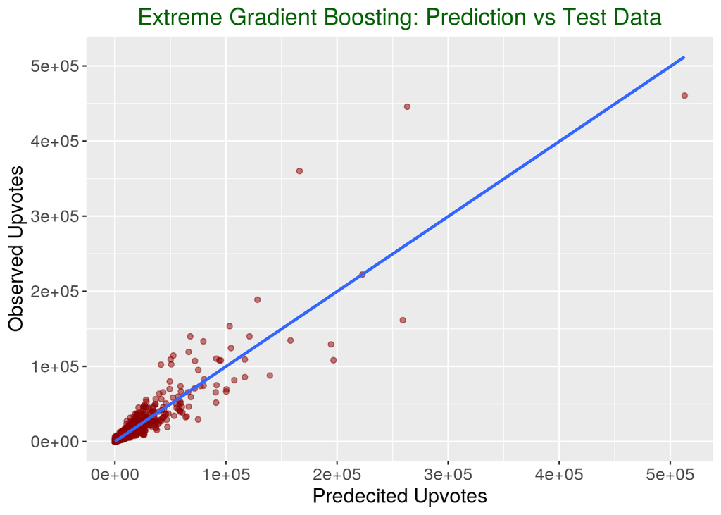

```r
pred <- predict(xgbmodel, newdata = mtest_set)

result <- as.data.frame(cbind(test_set$Upvotes, pred))

rmse_xgb <- as.integer(rmse(test_set$Upvotes, pred))

ggplot(result,aes(result$pred, result$V1)) + geom_point(color = "darkred", alpha = 0.5) +
  geom_smooth(method=lm)+ ggtitle('Linear Regression ') + ggtitle("Extreme Gradient Boosting: Prediction vs Test Data") +
  xlab("Predecited Upvotes") + ylab("Observed Upvotes") +
  theme(plot.title = element_text(color="darkgreen",size=16,hjust = 0.5),
        axis.text.y = element_text(size=12), axis.text.x = element_text(size=12,hjust=.5),
       axis.title.x = element_text(size=14), axis.title.y = element_text(size=14))
```

```r
rm(split, test_label,test_set, train_label, train_set, testdumb, traindumb,
   watchlist,xgbmodel, xgb_param, result, eval, mtest_set, mtrain_set)
```

For the XGBoost analysis, the RMSE for the testing sample is 1278.

### Keras analysis

```r
train_keras <- train_data %<>% mutate_if(is.factor, as.numeric)

#train_data <- train_data %>% filter(train_data$Views < 100000)
normalize <- function(x) {return ((x - min(x)) / (max(x) - min(x)))}

maxmin_data <- as.data.frame(lapply(train_keras, normalize))

maxmin_data <- as.matrix(maxmin_data)

ind <- sample(2, nrow(maxmin_data), replace = T, prob = c(.7, .3))
train_set <- maxmin_data[ind==1, 2:6]
test_set <- maxmin_data[ind==2, 2:6]

train_target <- maxmin_data[ind==1, 1]
test_target <- maxmin_data[ind==2, 1]
```

```r
k_model <- keras_model_sequential()
k_model %>%
  layer_dense(units = 15, activation = 'relu',
              kernel_initializer='RandomNormal',
              input_shape = c(5)) %>%
  layer_dense(units = 10, activation = 'relu') %>%
  layer_dense(units = 1, activation = 'linear')

#summary(k_model)

k_model %>% compile(
  loss = 'mean_squared_error',
  optimizer = 'adam',
  metrics = c('mae')
)
```

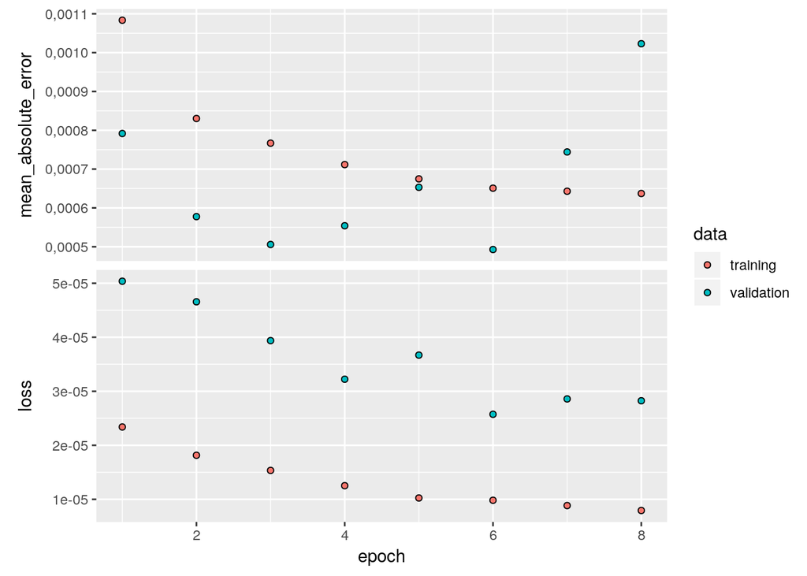

```r
k_hist <- k_model %>% fit(
  train_set, train_target,
  epochs = 8, batch_size = 80,
  validation_split = 0.1
)

plot(k_hist)
```

```r
k_model %>% evaluate(test_set, test_target)
```

```
## $loss
## [1] 9,805311e-06
##
## $mean_absolute_error
## [1] 0,0009987737
```

```r
pred <- data.frame(y = predict(k_model, as.matrix(test_set)))
predicted=pred$y * abs(diff(range(train_data$Upvotes))) + min(train_data$Upvotes)
actual=test_target * abs(diff(range(train_data$Upvotes))) + min(train_data$Upvotes)
result <- data.frame(predicted,actual)

rmse_keras <- as.integer(rmse(result$actual, result$predicted))
```

The RMSE for this model is 1926.

## SUMMARY RESULTS

The results of RMSE for each model is summarized below. There are some parameters to be fine tuned, which may decrease these values.

| METHOD | RMSE |
| --- | --- |
| Linear Regresion | 3274 |
| Non-linear Regresion | 2935 |
| XGBoost Analysis | 1278 |
| Keras Analysis | 1926 |